# Encodings_Practice slides

In this notebook, you'll be working with the Pokémon dataset from the univariate plots lesson.

**Task 1**: To start, let's look at the relationship between the Pokémon combat statistics of Speed, Defense, and Special-Defense. If a Pokémon has higher defensive statistics, does it necessarily sacrifice speed? Create a single plot to depict this relationship.

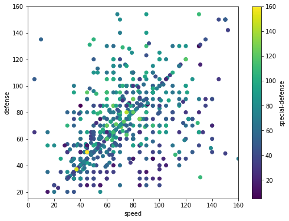

```python
plt.figure(figsize=[8,6])
plt.scatter(data=pokemon,x='defense',y='special-defense',c='speed')
plt.colorbar(label='special-defense')
plt.xlabel('speed')
plt.ylabel('defense')
plt.xlim(0,160)
plt.ylim(15,160);
```

To complete the second task, we need to first reshape the dataset so that all Pokémon types are recorded in a single column. This will add duplicates of Pokémon with two types, which is fine for the task to be performed.

```python
type_cols = ['type_1','type_2']
non_type_cols = pokemon.columns.difference(type_cols)
pkmn_types = pokemon.melt(id_vars = non_type_cols, value_vars = type_cols,
                          var_name = 'type_level', value_name = 'type').dropna()
pkmn_types.head()
```

|  | attack | base_experience | defense | generation_id | height | hp | id | special-attack | special-defense | species | speed | weight | type_level | type |
| --- | --- | --- | --- | --- | --- | --- | --- | --- | --- | --- | --- | --- | --- | --- |
| 0 | 49 | 64 | 49 | 1 | 0.7 | 45 | 1 | 65 | 65 | bulbasaur | 45 | 6.9 | type_1 | grass |
| 1 | 62 | 142 | 63 | 1 | 1.0 | 60 | 2 | 80 | 80 | ivysaur | 60 | 13.0 | type_1 | grass |
| 2 | 82 | 236 | 83 | 1 | 2.0 | 80 | 3 | 100 | 100 | venusaur | 80 | 100.0 | type_1 | grass |
| 3 | 52 | 62 | 43 | 1 | 0.6 | 39 | 4 | 60 | 50 | charmander | 65 | 8.5 | type_1 | fire |
| 4 | 64 | 142 | 58 | 1 | 1.1 | 58 | 5 | 80 | 65 | charmeleon | 80 | 19.0 | type_1 | fire |

**Task 2**: How do weights and heights compare between Fairy type Pokémon and Dragon type Pokémon? You may want to subset your dataframe before proceeding with the plotting code. **Hint**: If you remember from the univariate plots lesson, one of your axis variables may need to be transformed. If you plan on using FacetGrid, its `.set()` method will be vital for adjusting the axis scaling and tick marks. Check the [last example in the Seaborn documentation](https://seaborn.pydata.org/generated/seaborn.FacetGrid.html) for an example of how the `.set()` method is used, and the [matplotlib documentation of the Axes class](https://matplotlib.org/api/axes_api.html) for properties that you might want to set.

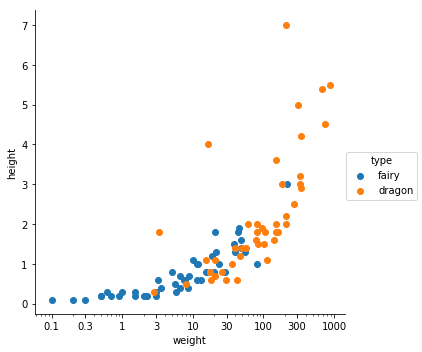

```python
# YOUR CODE HERE
g=sb.FacetGrid(data=pok_subset,hue='type',size=5)
g=g.map(plt.scatter,'weight','height')
g.set(xscale='log')
x_ticks = [0.1, 0.3, 1, 3, 10, 30, 100, 300, 1000]
g.set(xticks=x_ticks,xticklabels=x_ticks)
g.add_legend();
```